# R_RNA

by adding `fig.path = 'figures/'` we put all of the figures created when we knit this document into a directory called `figures`

# 1 Differential Expression Testing

Read the docs: https://bioconductor.org/packages/release/bioc/vignettes/DESeq2/inst/doc/DESeq2.html

Installs:

```r
# if (!requireNamespace("BiocManager", quietly = TRUE))
#     install.packages("BiocManager") # calls the package from the source
# BiocManager::install("GSEAbase")
# BiocManager::install("clusterProfiler")
# install.packages("devtools")
# install.packages("RColorBrewer")
# install.packages("pheatmap")
# devtools::install_github("karthik/wesanderson")
# BiocManager::install("org.Sc.sgd.db")
# BiocManager::install("GOstats")
# BiocManager::install("edgeR")
# BiocManager::install("tximport")
# BiocManager::install("DESeq2")
# install.packages("treemap")
# install.packages("tidyverse")
# install.packages("ggplot2")
```

Load Libraries:

```r
library(tximport)
library(DESeq2)
library(tidyverse)
library("GSEABase")
library(clusterProfiler)
library(RColorBrewer)
library(pheatmap)
library(wesanderson)
library(org.Sc.sgd.db)
library(GOstats)
library(edgeR)
library(treemap)
library(tidyverse)
library(ggplot2)
```

Import sample metadata:

```r
# read in the file from url
samples <- read_csv("https://osf.io/cxp2w/download")
# look at the first 6 lines
samples
```

```
## # A tibble: 6 x 3
##   sample    quant_file                                condition
##   <chr>     <chr>                                     <chr>
## 1 ERR458493 ~/quant/ERR458493.qc.fq.gz_quant/quant.sf wt
## 2 ERR458494 ~/quant/ERR458494.qc.fq.gz_quant/quant.sf wt
## 3 ERR458495 ~/quant/ERR458495.qc.fq.gz_quant/quant.sf wt
## 4 ERR458500 ~/quant/ERR458500.qc.fq.gz_quant/quant.sf snf2
## 5 ERR458501 ~/quant/ERR458501.qc.fq.gz_quant/quant.sf snf2
## 6 ERR458502 ~/quant/ERR458502.qc.fq.gz_quant/quant.sf snf2
```

```r
samples <- samples %>% mutate(quant_file = str_sub(quant_file, 3))
samples
```

```
## # A tibble: 6 x 3
##   sample    quant_file                              condition
##   <chr>     <chr>                                   <chr>
## 1 ERR458493 quant/ERR458493.qc.fq.gz_quant/quant.sf wt
## 2 ERR458494 quant/ERR458494.qc.fq.gz_quant/quant.sf wt
## 3 ERR458495 quant/ERR458495.qc.fq.gz_quant/quant.sf wt
## 4 ERR458500 quant/ERR458500.qc.fq.gz_quant/quant.sf snf2
## 5 ERR458501 quant/ERR458501.qc.fq.gz_quant/quant.sf snf2
## 6 ERR458502 quant/ERR458502.qc.fq.gz_quant/quant.sf snf2
```

Import tx 2 gene file:

```r
#tx2gene_map <- read_tsv("https://osf.io/a75zm/download")

tx <- read.table("quant/ERR458493.qc.fq.gz_quant/quant.sf", header = TRUE)
tx2gene_map <- data.frame(tx$Name, tx$Name)
names(tx2gene_map) <-  c("TXNAME", "GENEID")

txi <- tximport(files = samples$quant_file, type = "salmon", tx2gene = tx2gene_map)
```

```
## reading in files with read_tsv
```

```
## 1 2 3 4 5 6
## summarizing abundance
## summarizing counts
## summarizing length
```

```r
colnames(txi$counts) <- samples$sample
```

Make DESeq2 object:

```r
dds <- DESeqDataSetFromTximport(txi = txi,
                                colData = samples,
                                design = ~condition)
```

```
## using counts and average transcript lengths from tximport
```

```r
dds$condition <- relevel(dds$condition, ref = "wt") # make wild-type the reference to which expression in treatment samples is compared to
```

Run DESeq2:

```r
dds <- DESeq(dds)
```

```
## using 'avgTxLength' from assays(dds), correcting for library size
```

Check out results:

```r
res <- results(dds)
head(res)
```

```
## log2 fold change (MLE): condition snf2 vs wt
## Wald test p-value: condition snf2 vs wt
## DataFrame with 6 rows and 6 columns
##                                 baseMean      log2FoldChange              lfcSE
##                                <numeric>           <numeric>          <numeric>
## TRINITY_DN0_c0_g1_i1    1360.40678921768  -0.333459300846922 0.0519510512547458
## TRINITY_DN1_c0_g1_i1    949.123432273366   -3.38119274532714 0.0751783173559798
## TRINITY_DN10_c0_g1_i1   673.239604455581  0.0659692274383485  0.077025302767728
## TRINITY_DN10_c0_g1_i2   2332.28867108557   -0.74802777627825 0.0433016047709092
## TRINITY_DN100_c0_g1_i1  393.749558917206 -0.0732248347613759 0.0875518282734099
## TRINITY_DN1000_c0_g1_i1 5.16492387969525  0.0666414288239094  0.786803961402184
##                                       stat               pvalue
##                                  <numeric>            <numeric>
## TRINITY_DN0_c0_g1_i1      -6.4187209458338 1.37424048175215e-10
## TRINITY_DN1_c0_g1_i1     -44.9756374476529                    0
## TRINITY_DN10_c0_g1_i1    0.856461773831395    0.391742408236448
## TRINITY_DN10_c0_g1_i2    -17.2748280401097   7.279005087136e-67
## TRINITY_DN100_c0_g1_i1  -0.836359859130603    0.402952487486583
## TRINITY_DN1000_c0_g1_i1 0.0846988984462483     0.93250077173466
##                                         padj
##                                    <numeric>
## TRINITY_DN0_c0_g1_i1    2.23875272106954e-09
## TRINITY_DN1_c0_g1_i1                       0
## TRINITY_DN10_c0_g1_i1       0.61127063815258
## TRINITY_DN10_c0_g1_i2   4.96064196688319e-65
## TRINITY_DN100_c0_g1_i1     0.621195919512722
## TRINITY_DN1000_c0_g1_i1    0.969857727489006
```

Summarize results

```r
summary(res, alpha = 0.05) # default significance cut-off is 0.1, changing alpha to 0.05 changes the significance cut-off
```

```
##
## out of 9462 with nonzero total read count
## adjusted p-value < 0.05
## LFC > 0 (up)       : 774, 8.2%
## LFC < 0 (down)     : 1194, 13%
## outliers [1]       : 0, 0%
## low counts [2]     : 1284, 14%
## (mean count < 4)
## [1] see 'cooksCutoff' argument of ?results
## [2] see 'independentFiltering' argument of ?results
```

FDR (False Discovery Rate) adjusted p-values controls for the expected rate of false positives. The p-adj is almost always higher than the p-value. Controlling for multiple testing has the downside of increasing the possibility of false negatives.

Some researchers also set a cut-off for minimum expression and minimum log fold-changes.

If you want to use a log fold-change cut off:

```r
res_lfcut <- results(dds, lfcThreshold = 1, altHypothesis = "greaterAbs")
summary(res_lfcut, alpha = 0.05)
```

```
##
## out of 9462 with nonzero total read count
## adjusted p-value < 0.05
## LFC > 1.00 (up)    : 19, 0.2%
## LFC < -1.00 (down) : 169, 1.8%
## outliers [1]       : 0, 0%
## low counts [2]     : 1835, 19%
## (mean count < 5)
## [1] see 'cooksCutoff' argument of ?results
## [2] see 'independentFiltering' argument of ?results
```

Lets say you wanted the comparison to be in the other direction:

```r
res_rev <- results(dds, contrast=c("condition","wt", "snf2"))
head(res_rev)
```

```
## log2 fold change (MLE): condition wt vs snf2
## Wald test p-value: condition wt vs snf2
## DataFrame with 6 rows and 6 columns
##                                 baseMean      log2FoldChange              lfcSE
##                                <numeric>           <numeric>          <numeric>
## TRINITY_DN0_c0_g1_i1    1360.40678921768   0.333459300846922 0.0519510512547458
## TRINITY_DN1_c0_g1_i1    949.123432273366    3.38119274532714 0.0751783173559798
## TRINITY_DN10_c0_g1_i1   673.239604455581 -0.0659692274383485  0.077025302767728
## TRINITY_DN10_c0_g1_i2   2332.28867108557    0.74802777627825 0.0433016047709092
## TRINITY_DN100_c0_g1_i1  393.749558917206  0.0732248347613759 0.0875518282734099
## TRINITY_DN1000_c0_g1_i1 5.16492387969525 -0.0666414288239094  0.786803961402184
##                                        stat               pvalue
##                                   <numeric>            <numeric>
## TRINITY_DN0_c0_g1_i1        6.4187209458338 1.37424048175215e-10
## TRINITY_DN1_c0_g1_i1       44.9756374476529                    0
## TRINITY_DN10_c0_g1_i1    -0.856461773831395    0.391742408236448
## TRINITY_DN10_c0_g1_i2      17.2748280401097   7.279005087136e-67
## TRINITY_DN100_c0_g1_i1    0.836359859130603    0.402952487486583
## TRINITY_DN1000_c0_g1_i1 -0.0846988984462483     0.93250077173466
##                                         padj
##                                    <numeric>
## TRINITY_DN0_c0_g1_i1    2.23875272106954e-09
## TRINITY_DN1_c0_g1_i1                       0
## TRINITY_DN10_c0_g1_i1       0.61127063815258
## TRINITY_DN10_c0_g1_i2   4.96064196688319e-65
## TRINITY_DN100_c0_g1_i1     0.621195919512722
## TRINITY_DN1000_c0_g1_i1    0.969857727489006
```

# 2 Visualizing RNA-seq results

## 2.1 Normalization

**Count Data Transformations:** for ranking and visualizations (e.g. PCA plots and heatmaps)

**rlog**: “transforms the count data to the log2 scale in a way which minimizes differences between samples for rows with small counts, and which normalizes with respect to library size. The rlog transformation produces a similar variance stabilizing effect as varianceStabilizingTransformation, though rlog is more robust in the case when the size factors vary widely. The transformation is useful when checking for outliers or as input for machine learning techniques such as clustering or linear discriminant analysis.” – from function documentation

This is computationally very time intensive.

```r
rld <- rlog(dds, blind=TRUE)
head(assay(rld), 3)
```

```
##                       ERR458493 ERR458494 ERR458495 ERR458500 ERR458501
## TRINITY_DN0_c0_g1_i1  10.515190 10.474204 10.529531 10.279211 10.269616
## TRINITY_DN1_c0_g1_i1  10.245816 10.260872 10.248551  8.069395  8.207987
## TRINITY_DN10_c0_g1_i1  9.478571  9.375756  9.251608  9.409108  9.376002
##                       ERR458502
## TRINITY_DN0_c0_g1_i1  10.336747
## TRINITY_DN1_c0_g1_i1   8.253291
## TRINITY_DN10_c0_g1_i1  9.456133
```

** Variance stabilizing transformation (so much faster than rlog):** “This function calculates a variance stabilizing transformation (VST) from the fitted dispersion-mean relation(s) and then transforms the count data (normalized by division by the size factors or normalization factors), yielding a matrix of values which are now approximately homoskedastic (having constant variance along the range of mean values). The transformation also normalizes with respect to library size. The rlog is less sensitive to size factors, which can be an issue when size factors vary widely. These transformations are useful when checking for outliers or as input for machine learning techniques such as clustering or linear discriminant analysis.”" – from function documentation

```r
vsd <- vst(dds, blind = TRUE)
head(assay(vsd), 3)
```

```
##                       ERR458493 ERR458494 ERR458495 ERR458500 ERR458501
## TRINITY_DN0_c0_g1_i1  10.601522 10.538421 10.623577 10.234463 10.219242
## TRINITY_DN1_c0_g1_i1  10.768652 10.789645 10.772542  7.350940  7.607800
## TRINITY_DN10_c0_g1_i1  9.573273  9.414877  9.220443  9.466294  9.415451
##                       ERR458502
## TRINITY_DN0_c0_g1_i1  10.325053
## TRINITY_DN1_c0_g1_i1   7.689702
## TRINITY_DN10_c0_g1_i1  9.538158
```

## 2.2 Ordination

rlog PCA:

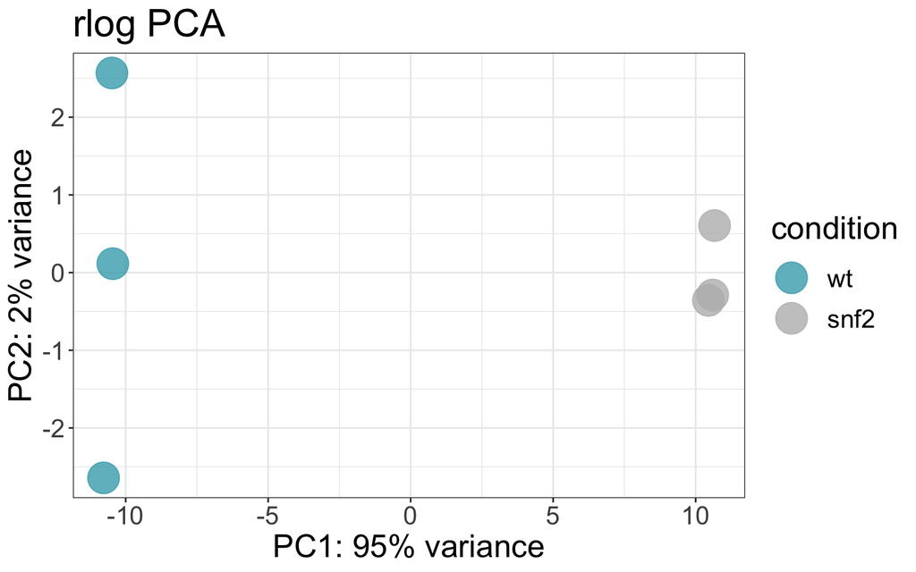

```r
data1 <- plotPCA(rld, returnData=TRUE)
data1$group<-gsub(" : ","_",as.character(data1$group))
percentVar1 <- round(100 * attr(data1, "percentVar"))

PCA<-ggplot(data1, aes(PC1, PC2, color = condition))+ theme_bw()+
  geom_point(size=9, alpha = 0.8) + scale_colour_manual(values = c("#44aabb","#bbbbbb"))+
  xlab(paste0("PC1: ",percentVar1[1],"% variance")) +
  ylab(paste0("PC2: ",percentVar1[2],"% variance")) +
  theme(text = element_text(size=20)) + ggtitle("rlog PCA")
PCA
```

```r
#ggsave("figures/vsd_PCA.png", device="png") # to save the plot
```

variance stabilized PCA:

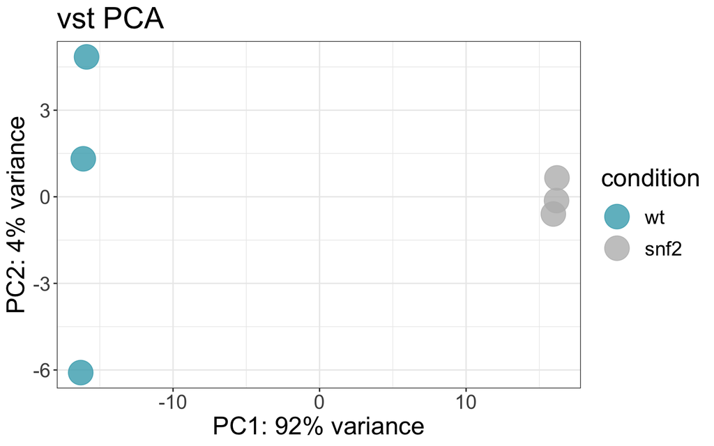

```r
data1 <- plotPCA(vsd, returnData=TRUE)
data1$group<-gsub(" : ","_",as.character(data1$group))
percentVar1 <- round(100 * attr(data1, "percentVar"))

PCA<-ggplot(data1, aes(PC1, PC2, color = condition))+ theme_bw()+
  geom_point(size=9, alpha = 0.8) + scale_colour_manual(values = c("#44aabb","#bbbbbb"))+
  xlab(paste0("PC1: ",percentVar1[1],"% variance")) +
  ylab(paste0("PC2: ",percentVar1[2],"% variance")) +
  theme(text = element_text(size=20)) + ggtitle("vst PCA")
PCA
```

```r
#ggsave("figures/vsd_PCA.png", device="png") # to save the plot
```

## 2.3 HeatMaps

rlog HeatMap:

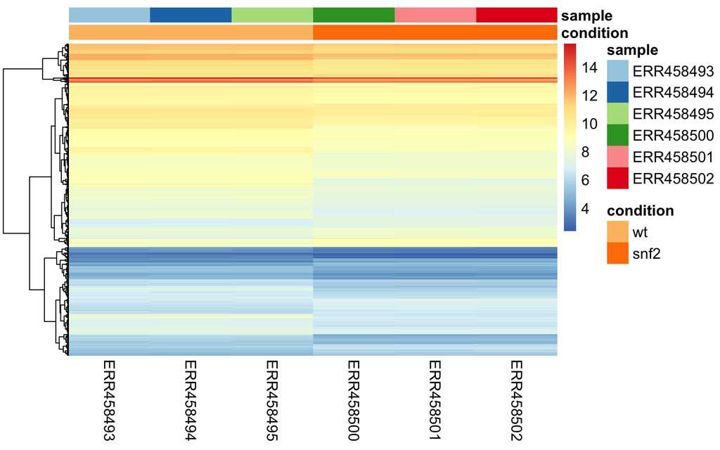

```r
df <- as.data.frame(colData(rld)[,c("condition", "sample")])

mat_colors1<-list(sample = brewer.pal(12, "Paired")[0:6])
names(mat_colors1$sample)<- df$sample

mat_colors <- list(condition = brewer.pal(12, "Paired")[7:8])
names(mat_colors$condition) <- c("wt", "snf2")

genes <- order(res$padj)[1:1000]

 pheatmap(assay(rld)[genes, ], cluster_rows=TRUE, show_rownames=FALSE,
         cluster_cols=FALSE, annotation_col=df, annotation_colors = c(mat_colors1, mat_colors), fontsize = 12)
```

variance stabilized HeatMap:

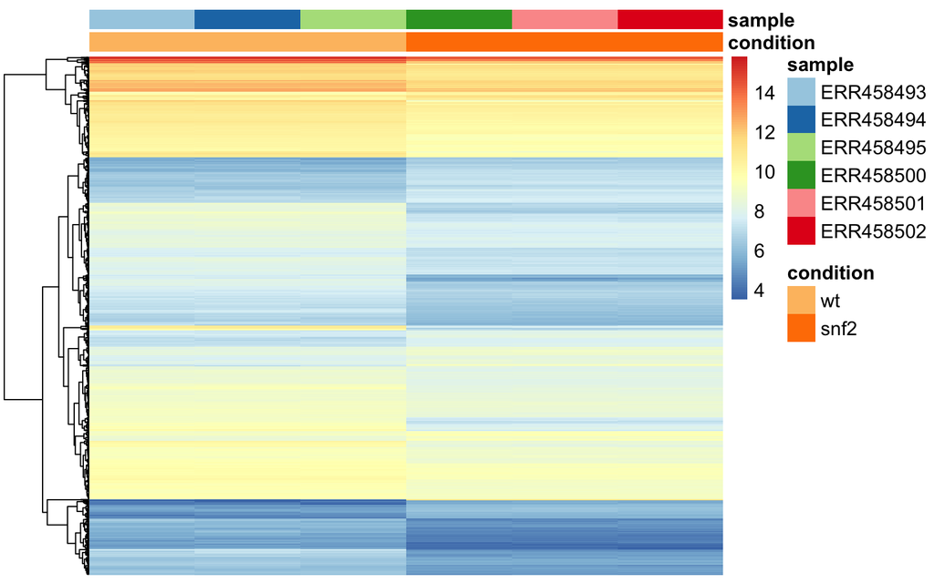

```r
df <- as.data.frame(colData(vsd)[,c("condition", "sample")])

pheatmap(assay(vsd)[genes, ], cluster_rows=TRUE, show_rownames=FALSE, show_colnames = FALSE,
         cluster_cols=FALSE, annotation_col=df, annotation_colors = c(mat_colors1, mat_colors), fontsize = 12)
```

Another option for heat maps: plot the difference from the mean normalized count across samples (and optionally change default colors)

With Rlog transformed data:

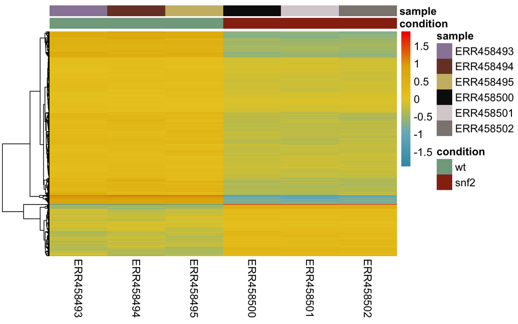

```r
library(wesanderson)
pal <- wes_palette(name = "Zissou1", n=2000 , type= "continuous")

mat_colors1<-list(sample = wes_palette("IsleofDogs1", 6))
names(mat_colors1$sample)<- df$sample

mat_colors <- list(condition = wes_palette("Cavalcanti1")[4:5])
names(mat_colors$condition) <- c("wt", "snf2")

mat <- assay(rld)[genes, ]
mat <- mat - rowMeans(mat)

df <- as.data.frame(colData(rld)[,c("condition", "sample")])

pheatmap(mat,  cluster_rows=TRUE, show_rownames=FALSE,
         cluster_cols=FALSE, annotation_col=df, annotation_colors = c(mat_colors1, mat_colors), fontsize = 12, color = pal)
```

Same but with variance stabilizing function:

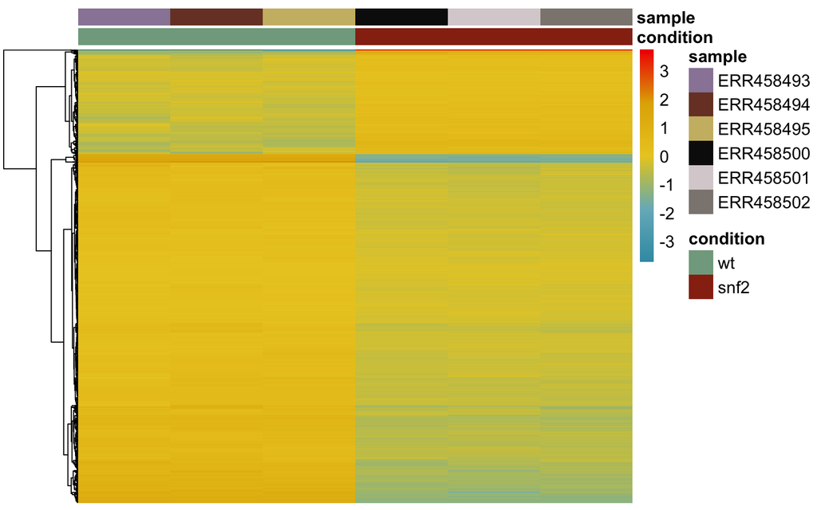

```r
mat <- assay(vsd)[genes, ]
mat <- mat - rowMeans(mat)

df <- as.data.frame(colData(vsd)[,c("condition", "sample")])

pheatmap(mat,  cluster_rows=TRUE, show_rownames=FALSE, show_colnames = FALSE,
         cluster_cols=FALSE, annotation_col=df, annotation_colors = c(mat_colors1, mat_colors), fontsize = 12, color = pal)
```

Heatmap of sample-to-sample distances

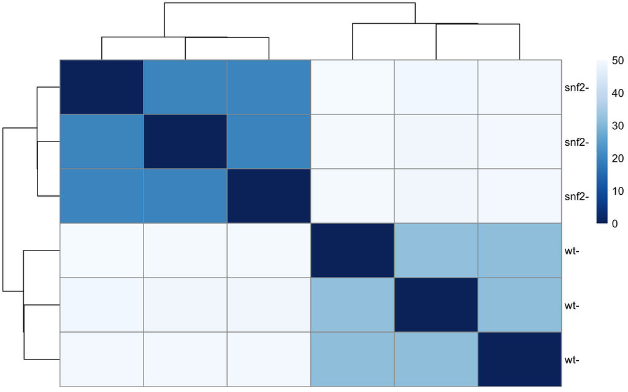

```r
sampleDists <- dist(t(assay(vsd)))
sampleDistMatrix <- as.matrix(sampleDists)
rownames(sampleDistMatrix) <- paste(vsd$condition, vsd$type, sep="-")
colnames(sampleDistMatrix) <- NULL
colors <- colorRampPalette( rev(brewer.pal(9, "Blues")) )(255)
pheatmap(sampleDistMatrix,
         clustering_distance_rows=sampleDists,
         clustering_distance_cols=sampleDists,
         col=colors)
```

## 2.4 MA plot

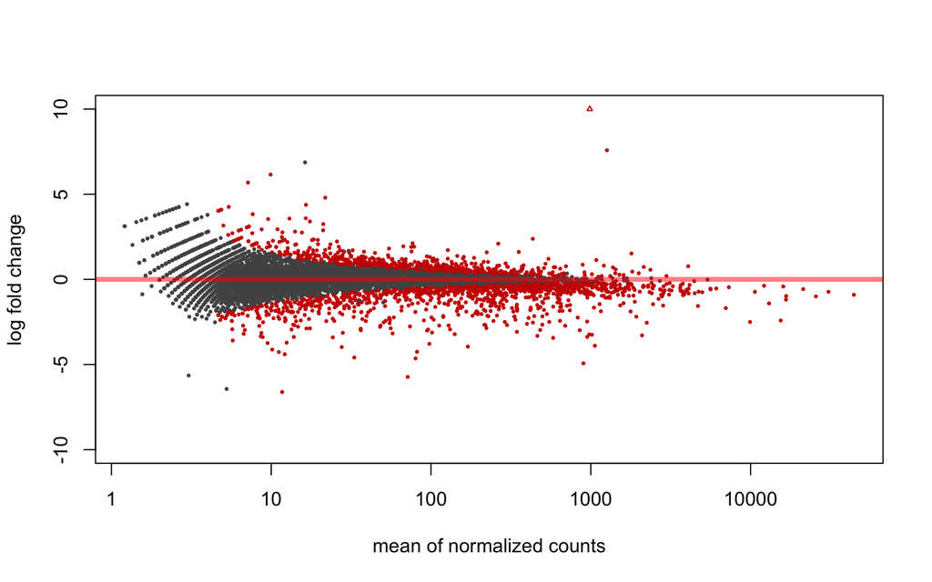

```r
DESeq2::plotMA(res, alpha = 0.05, ylim = c(-10,10))
```

```r
#default alpha is 0.1
```

# 3 Gene Set Enrichment Testing

If you remember, we had 774 significantly upregulated genes and 1194 significantly down regulated genes in this data set (this is pretty typical). That is a lot to try to make sense of. If you know you are interested in a specific gene or a specific pathway, you can look for that in your data, but if you are trying to figure out what is generally different between treatments, it helps to categaorize and summarize genes by what they do. Two common ways to do this are GO terms and KEGG pathways.

```r
summary(res, alpha = 0.05)
```

```
##
## out of 9462 with nonzero total read count
## adjusted p-value < 0.05
## LFC > 0 (up)       : 774, 8.2%
## LFC < 0 (down)     : 1194, 13%
## outliers [1]       : 0, 0%
## low counts [2]     : 1284, 14%
## (mean count < 4)
## [1] see 'cooksCutoff' argument of ?results
## [2] see 'independentFiltering' argument of ?results
```

## 3.1 Annotations

we need to line up our pfam and GOannotatations with the differential expression results

```r
#get dataframe of significantly differentially expressed genes
DEres <- as.data.frame(res)
DEres$trinity <- row.names(DEres)
sigDEgenes <- subset(DEres, padj < 0.05)
sigDEgenes$trinity <- row.names(sigDEgenes)
```

Import and wrangle Pfam anotations

```r
pfamAnnotation <- read_csv("Trinity.fasta.x.pfam-A.csv") %>% group_by(query_name) %>% filter(rank(full_evalue, ties.method="first")==1) %>% arrange(query_name) %>% separate(target_accession, c("Pfam", "version"), sep = "\\.") %>% dplyr::select(Pfam, target_name, description, query_name)
length(pfamAnnotation$Pfam)
```

```
## [1] 4939
```

4939 out of 9462 “genes” have good Pfam annotations

GO term to pfam mapping is available from: http://current.geneontology.org/ontology/external2go/pfam2go.

import and wrangle pfam2go mapping file:

```r
pfam2go <- read.delim("pfam2go4R.txt", header = FALSE) %>%
  separate(V1, c('V1_1', 'V1_2'), sep = '>') %>%
  separate(V1_1, c("Pfam", "name"), sep = " ") %>%
  separate(V1_2, c("GO_desc", "GO"), sep = ";") %>% mutate(GO = str_sub(GO, 2)) %>% mutate(Pfam= str_sub(Pfam, 6))
```

Merger pfam annotations and pfam2GO mapping:

```r
pfamGO <- left_join(as_tibble(pfamAnnotation), as_tibble(pfam2go))
#how many unique pfam annotations with GO terms?
length(unique(pfamGO$Pfam))
```

```
## [1] 2296
```

import and wrangle trinity name to dammit rename file:

```r
namemap<-read_csv("Trinity.fasta.dammit.namemap.csv") %>% separate(original, c("trinity"), sep = " ") %>% rename(query_name = "renamed")
finalmapping<- right_join(namemap, pfamGO)
```

```r
#(format transcript to GO mapping for GOstats)
GOdf <- data.frame(finalmapping$trinity, finalmapping$GO)
GOdf$evidence <- "ISS"
names(GOdf) <- c("isoform", "GO", "evidence")
#reorder columns
GOdf <- GOdf[,c("GO","evidence","isoform")]
GOdf$GO <- as.character(GOdf$GO)
GOdf$isoform<- as.character(GOdf$isoform)
goframe=GOFrame(GOdf)
goAllFrame=GOAllFrame(goframe)
```

[output not shown]

```r
gsc <- GeneSetCollection(goAllFrame, setType = GOCollection())


universe <-namemap$trinity
```

```r
sigDEgenes <- subset(DEres, padj < 0.05)
sigAnnotated <- left_join(sigDEgenes, finalmapping)
#make list of upregulated genes
sigDEup <- sigDEgenes[sigDEgenes$log2FoldChange >0,]
uplist <- sigDEup$trinity
#make list of downregulated genes
sigDEdown<- sigDEgenes[sigDEgenes$log2FoldChange <0,]
downlist <- sigDEdown$trinity
```

## 3.2 GO term enrichment

“A GO annotation is a statement about the function of a particular gene. GO annotations are created by associating a gene or gene product with a GO term. Together, these statements comprise a “snapshot” of current biological knowledge. Hence, GO annotations capture statements about how a gene functions at the molecular level, where in the cell it functions, and what biological processes (pathways, programs) it helps to carry out.

Different pieces of knowledge regarding gene function may be established to different degrees, which is why each GO annotation always refers to the evidence upon which it is based. All GO annotations are ultimately supported by the scientific literature, either directly or indirectly. In GO, the supporting evidence is presented in the form of a GO Evidence Codes and either a published reference or description of the methodology used to create the annotation. The GO evidence codes describe the type of evidence and reflect how far removed the annotated assertion is from direct experimental evidence, and whether this evidence was reviewed by an expert biocurator." – http://geneontology.org/docs/go-annotations/

```r
#GOterm enrichment in up-regulated genes:
upregulated = hyperGTest(
  GSEAGOHyperGParams(name = "snf2 upregged",
                     geneSetCollection=gsc,geneIds = uplist,
                     universeGeneIds=universe,ontology = "BP",pvalueCutoff = 0.05,conditional = FALSE,testDirection = "over"))
upregulated
```

```
## Gene to GO BP  test for over-representation
## 478 GO BP ids tested (106 have p < 0.05)
## Selected gene set size: 174
##     Gene universe size: 1841
##     Annotation package: Based on a GeneSetCollection Object
```

```r
htmlReport(upregulated, file="enrichedUPgostats.html")
upgoterms <-data.frame(summary(upregulated))
#write.csv(upgoterms,"upgo.csv")
```

```r
upgoterms$Term
```

```
##   [1] "ion transmembrane transport"
##   [2] "inorganic ion transmembrane transport"
##   [3] "inorganic cation transmembrane transport"
##   [4] "cation transmembrane transport"
##   [5] "energy coupled proton transport, down electrochemical gradient"
##   [6] "ATP synthesis coupled proton transport"
##   [7] "cell redox homeostasis"
##   [8] "cation transport"
##   [9] "localization"
##  [10] "ion transport"
##  [11] "carboxylic acid transmembrane transport"
##  [12] "organic anion transport"
##  [13] "monocarboxylic acid transport"
##  [14] "organic acid transport"
##  [15] "mitochondrial pyruvate transmembrane transport"
```

[output cut: 91 more lines]

**GOterm enrichment among significantly DOWNreguated genes:**

```
## Gene to GO BP  test for over-representation
## 523 GO BP ids tested (92 have p < 0.05)
## Selected gene set size: 424
##     Gene universe size: 1841
##     Annotation package: Based on a GeneSetCollection Object
```

##ReviGO Plot to visualize GO term enrichment results

Results were imported into ReviGO, summarizes long lists of GO terms by removing redundant terms and clustering terms with similar meanings.

```r
revigo.names <- c("term_ID","description","frequency_%","plot_X","plot_Y","plot_size","value","uniqueness","dispensability");
revigo.data <- rbind(c("GO:0000726","non-recombinational repair", 0.050,-2.710, 3.637, 3.811, 1.0000,0.837,0.000),
c("GO:0008152","metabolic process",75.387, 0.614,-2.095, 6.986, 0.0000,0.997,0.000),
c("GO:0009117","nucleotide metabolic process", 4.166,-4.553,-3.763, 5.728, 0.0000,0.466,0.000),
c("GO:0034220","ion transmembrane transport", 3.528, 6.208,-2.001, 5.656, 1.0000,0.774,0.000),
c("GO:0051179","localization",18.495, 0.415,-0.039, 6.375, 1.0000,0.992,0.000),
c("GO:0065008","regulation of biological quality", 3.395, 1.278,-5.548, 5.639, 1.0000,0.970,0.000),
c("GO:0071840","cellular component organization or biogenesis", 8.568, 1.853,-3.991, 6.041, 1.0000,0.990,0.000),
c("GO:0007029","endoplasmic reticulum organization", 0.032, 4.009, 4.791, 3.617, 1.0000,0.941,0.021),
c("GO:0009056","catabolic process", 4.820, 2.523,-1.180, 5.791, 0.0000,0.964,0.022),
c("GO:0071554","cell wall organization or biogenesis", 0.950, 2.900,-2.495, 5.086, 1.0000,0.946,0.027),
c("GO:0009058","biosynthetic process",31.611, 2.398,-2.009, 6.608, 0.0000,0.956,0.033),
c("GO:0042737","drug catabolic process", 0.001, 0.782, 3.197, 2.286, 0.0000,0.900,0.042),
c("GO:0090407","organophosphate biosynthetic process", 4.110,-5.521, 2.779, 5.722, 1.0000,0.580,0.055),
c("GO:0017144","drug metabolic process", 0.058, 0.462,-1.061, 3.868, 0.0000,0.929,0.056),
c("GO:0046486","glycerolipid metabolic process", 0.593,-2.347,-7.356, 4.881, 1.0000,0.774,0.072),
c("GO:1901135","carbohydrate derivative metabolic process", 6.319, 1.524, 0.788, 5.909, 1.0000,0.913,0.075),
c("GO:0006733","oxidoreduction coenzyme metabolic process", 1.273, 0.639, 3.927, 5.213, 0.0000,0.865,0.079),
c("GO:0006091","generation of precursor metabolites and energy", 1.940, 2.105, 1.217, 5.396, 0.0000,0.903,0.084),
c("GO:0010467","gene expression",19.671,-0.620, 6.991, 6.402, 0.0000,0.881,0.093),
c("GO:0005975","carbohydrate metabolic process", 5.260, 0.741, 2.005, 5.829, 0.0000,0.902,0.098),
c("GO:0006000","fructose metabolic process", 0.022,-3.320,-6.041, 3.458, 1.0000,0.762,0.116),
c("GO:0006388","tRNA splicing, via endonucleolytic cleavage and ligation", 0.040,-2.601, 4.599, 3.706, 1.0000,0.828,0.157),
c("GO:0006112","energy reserve metabolic process", 0.168,-1.526,-7.706, 4.334, 0.0000,0.809,0.195),
c("GO:0016051","carbohydrate biosynthetic process", 1.079,-6.138,-3.253, 5.141, 0.0000,0.688,0.204),
c("GO:0072524","pyridine-containing compound metabolic process", 1.351,-5.667,-0.357, 5.239, 0.0000,0.764,0.228),
c("GO:0043603","cellular amide metabolic process", 6.879,-5.153, 0.910, 5.946, 0.0000,0.804,0.242),
c("GO:0032507","maintenance of protein location in cell", 0.057, 3.601,-5.348, 3.868, 1.0000,0.672,0.255),
c("GO:1901137","carbohydrate derivative biosynthetic process", 3.651,-5.366, 3.669, 5.671, 1.0000,0.764,0.255),
c("GO:1901564","organonitrogen compound metabolic process",17.886,-5.069, 1.674, 6.361, 0.0000,0.810,0.264),
c("GO:1901576","organic substance biosynthetic process",30.365,-5.821, 3.462, 6.591, 0.0000,0.780,0.275),
c("GO:0052803","imidazole-containing compound metabolic process", 0.420,-6.364,-0.441, 4.732, 0.0000,0.788,0.289),
c("GO:0006839","mitochondrial transport", 0.182, 6.220,-0.937, 4.369, 1.0000,0.874,0.296),
c("GO:0015931","nucleobase-containing compound transport", 0.198, 5.878,-1.374, 4.404, 1.0000,0.833,0.299),
c("GO:0055114","oxidation-reduction process",15.060,-3.403,-7.152, 6.286, 0.0000,0.769,0.310),
c("GO:0019538","protein metabolic process",18.489,-0.950, 6.815, 6.375, 0.0000,0.869,0.339),
c("GO:0072521","purine-containing compound metabolic process", 2.673,-5.665, 0.029, 5.535, 0.0000,0.744,0.357),
c("GO:0072522","purine-containing compound biosynthetic process", 1.502,-6.315, 0.777, 5.285, 0.0000,0.669,0.361),
c("GO:0071555","cell wall organization", 0.709, 4.128, 4.999, 4.959, 1.0000,0.915,0.375),
c("GO:0044281","small molecule metabolic process",15.138,-3.256,-6.959, 6.288, 0.0000,0.769,0.415),
c("GO:0006418","tRNA aminoacylation for protein translation", 1.099,-5.437,-1.496, 5.149, 0.0000,0.579,0.417),
c("GO:0019439","aromatic compound catabolic process", 1.164,-2.172, 0.819, 5.174, 0.0000,0.775,0.425),
c("GO:0044267","cellular protein metabolic process",14.293,-2.084, 5.969, 6.263, 0.0000,0.840,0.426),
c("GO:0010256","endomembrane system organization", 0.189, 3.448, 4.288, 4.385, 1.0000,0.933,0.434),
c("GO:0051236","establishment of RNA localization", 0.101, 6.361,-2.918, 4.111, 1.0000,0.836,0.472),
c("GO:0006090","pyruvate metabolic process", 0.817,-3.803,-6.807, 5.021, 0.0000,0.669,0.475),
c("GO:0042866","pyruvate biosynthetic process", 0.005,-5.049,-5.389, 2.780, 0.0000,0.737,0.488),
c("GO:0006487","protein N-linked glycosylation", 0.076,-4.680,-1.784, 3.992, 1.0000,0.754,0.493),
c("GO:0006403","RNA localization", 0.118, 5.789,-2.639, 4.179, 1.0000,0.856,0.497),
c("GO:0045229","external encapsulating structure organization", 0.795, 3.535, 4.653, 5.009, 1.0000,0.925,0.498),
c("GO:1901566","organonitrogen compound biosynthetic process",14.064,-6.317, 0.855, 6.256, 0.0000,0.682,0.506),
c("GO:0055086","nucleobase-containing small molecule metabolic process", 4.917,-4.920,-4.419, 5.800, 0.0000,0.608,0.518),
c("GO:0015849","organic acid transport", 1.024, 5.627,-3.839, 5.119, 1.0000,0.738,0.527),
c("GO:0071166","ribonucleoprotein complex localization", 0.097, 6.117,-3.030, 4.094, 1.0000,0.845,0.529),
c("GO:0006302","double-strand break repair", 0.211,-3.379, 4.862, 4.432, 1.0000,0.818,0.540),
c("GO:0019725","cellular homeostasis", 1.253,-0.668,-7.416, 5.206, 1.0000,0.765,0.552),
c("GO:0034645","cellular macromolecule biosynthetic process",19.291,-5.062, 3.332, 6.394, 0.0000,0.748,0.555),
c("GO:0009059","macromolecule biosynthetic process",19.548,-5.044, 4.271, 6.399, 0.0000,0.779,0.558),
c("GO:0006810","transport",17.616, 6.563,-2.324, 6.354, 1.0000,0.805,0.560),
c("GO:0006556","S-adenosylmethionine biosynthetic process", 0.050,-2.714, 5.972, 3.810, 0.0000,0.838,0.562),
c("GO:0015718","monocarboxylic acid transport", 0.155, 6.002,-1.867, 4.299, 1.0000,0.734,0.565),
c("GO:0046394","carboxylic acid biosynthetic process", 4.159,-5.321,-4.037, 5.727, 0.0000,0.550,0.575),
c("GO:0009072","aromatic amino acid family metabolic process", 0.719,-4.716,-4.801, 4.965, 0.0000,0.640,0.577),
c("GO:0006414","translational elongation", 0.777,-6.028, 1.758, 4.999, 0.0000,0.721,0.577),
c("GO:1901136","carbohydrate derivative catabolic process", 0.423,-0.138, 4.014, 4.735, 0.0000,0.814,0.582),
c("GO:0044271","cellular nitrogen compound biosynthetic process",22.502,-6.173, 1.273, 6.460, 0.0000,0.709,0.587),
c("GO:0006913","nucleocytoplasmic transport", 0.237, 5.489,-2.450, 4.483, 1.0000,0.813,0.587),
c("GO:0046500","S-adenosylmethionine metabolic process", 0.090, 1.208, 5.818, 4.062, 0.0000,0.880,0.591),
c("GO:0006082","organic acid metabolic process", 9.086,-3.977,-6.024, 6.067, 0.0000,0.606,0.592),
c("GO:0051235","maintenance of location", 0.129, 5.215,-4.639, 4.219, 1.0000,0.853,0.593),
c("GO:0006850","mitochondrial pyruvate transport", 0.015, 6.471,-1.564, 3.282, 1.0000,0.762,0.594),
c("GO:0046434","organophosphate catabolic process", 0.365,-1.444, 0.855, 4.671, 0.0000,0.662,0.596),
c("GO:0016043","cellular component organization", 7.239, 4.098, 5.023, 5.968, 1.0000,0.910,0.602),
c("GO:0050657","nucleic acid transport", 0.100, 6.703,-0.731, 4.108, 1.0000,0.829,0.604),
c("GO:0043038","amino acid activation", 1.124,-4.483,-4.976, 5.159, 0.0000,0.628,0.605),
c("GO:0006811","ion transport", 5.344, 6.702,-2.153, 5.836, 1.0000,0.828,0.609),
c("GO:0000041","transition metal ion transport", 0.344, 6.793,-1.351, 4.645, 1.0000,0.817,0.615),
c("GO:0046474","glycerophospholipid biosynthetic process", 0.266,-5.351,-3.787, 4.534, 1.0000,0.590,0.635),
c("GO:0016052","carbohydrate catabolic process", 1.078,-1.478,-2.051, 5.141, 0.0000,0.826,0.643),
c("GO:0006826","iron ion transport", 0.133, 6.716,-1.102, 4.233, 1.0000,0.820,0.654),
c("GO:0044283","small molecule biosynthetic process", 5.677,-5.610,-3.730, 5.862, 0.0000,0.590,0.654),
c("GO:0006643","membrane lipid metabolic process", 0.382,-2.290,-7.585, 4.690, 1.0000,0.783,0.657),
c("GO:0044249","cellular biosynthetic process",30.048,-6.423, 2.450, 6.586, 0.0000,0.762,0.658),
c("GO:0033365","protein localization to organelle", 0.609, 6.157,-2.805, 4.893, 1.0000,0.806,0.684),
c("GO:0051169","nuclear transport", 0.239, 5.501,-2.340, 4.486, 1.0000,0.829,0.684),
c("GO:0055085","transmembrane transport", 8.916, 6.686,-2.407, 6.058, 1.0000,0.819,0.684),
c("GO:0009312","oligosaccharide biosynthetic process", 0.248,-6.027,-3.322, 4.502, 0.0000,0.720,0.687),
c("GO:0044272","sulfur compound biosynthetic process", 1.235,-4.762, 4.724, 5.200, 0.0000,0.829,0.689),
c("GO:0000105","histidine biosynthetic process", 0.360,-5.721,-2.720, 4.664, 0.0000,0.617,0.691),
c("GO:1901605","alpha-amino acid metabolic process", 3.625,-4.749,-4.604, 5.668, 0.0000,0.580,0.698));

one.data <- data.frame(revigo.data);
names(one.data) <- revigo.names;
one.data <- one.data [(one.data$plot_X != "null" & one.data$plot_Y != "null"), ];
one.data$plot_X <- as.numeric( as.character(one.data$plot_X) );
one.data$plot_Y <- as.numeric( as.character(one.data$plot_Y) );
one.data$plot_size <- as.numeric( as.character(one.data$plot_size) );
one.data$frequency <- as.numeric( as.character(one.data$frequency) );
one.data$uniqueness <- as.numeric( as.character(one.data$uniqueness) );
one.data$dispensability <- as.numeric( as.character(one.data$dispensability) );
ex <- one.data [ one.data$dispensability < 0.15, ]
```

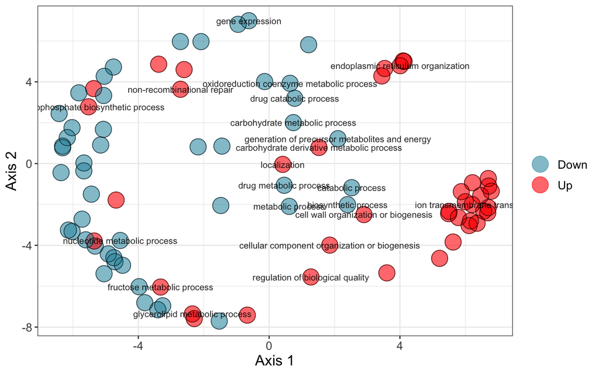

```r
one.data$value <- gsub('0', 'Down', one.data$value)
one.data$value <- gsub('1', 'Up', one.data$value)

reviGOplot <- ggplot( data = one.data ) +
  geom_point( aes( plot_X, plot_Y, colour = value), alpha = I(0.6), size =7) +
  scale_colour_manual(values =c("#3B9AB2", "red"), labels= c("Down", "Up")) +
  geom_point( aes(plot_X, plot_Y), shape = 21, fill = "transparent", colour = I (alpha ("black", 0.6) ), size = 7) +   scale_size_area() + scale_size( range=c(5, 30)) + theme_bw() + theme(legend.key = element_blank()) + theme(text = element_text(size=14)) + theme(legend.title=element_blank()) +labs (y = "Axis 2", x = "Axis 1") +geom_text( data = ex, aes(plot_X, plot_Y, label = description), colour = I(alpha("black", 0.85)), size = 3 )
#+geom_label_repel(data = ex, aes(plot_X, plot_Y, label = description), colour = I(alpha("black", 0.85)), size = 4, nudge_x = 0 , point.padding = 0.2, label.padding = 0.1)+ labs (y = "Axis 2", x = "Axis 1")
# need library ggrepel
# install.packages("ggrepel")
#library(ggrepel

reviGOplot
```

### 3.2.1 treemap

```
## Note: tmPlot deprecated as of version 2.0. Please use treemap instead.
```

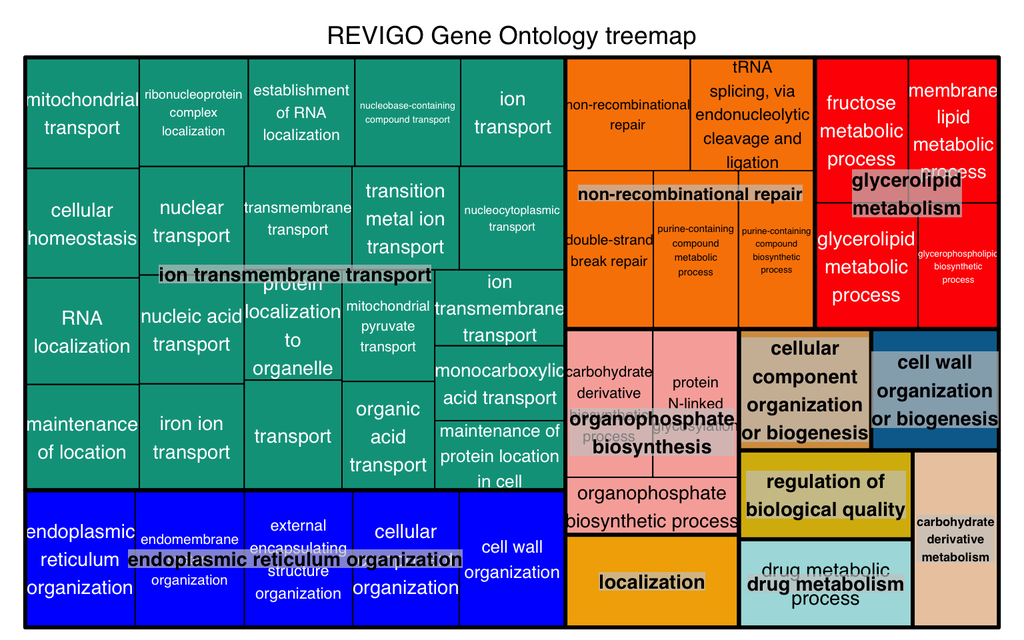

```r
revigo.names <- c("term_ID","description","freqInDbPercent","value","uniqueness","dispensability","representative");
revigo.data <- rbind(c("GO:0000726","non-recombinational repair",0.050,1.0000,0.867,0.000,"non-recombinational repair"),
c("GO:0006302","double-strand break repair",0.211,1.0000,0.854,0.540,"non-recombinational repair"),
c("GO:0006388","tRNA splicing, via endonucleolytic cleavage and ligation",0.040,1.0000,0.864,0.157,"non-recombinational repair"),
c("GO:0072522","purine-containing compound biosynthetic process",1.502,1.0000,0.743,0.361,"non-recombinational repair"),
c("GO:0072521","purine-containing compound metabolic process",2.673,1.0000,0.825,0.153,"non-recombinational repair"),
c("GO:0034220","ion transmembrane transport",3.528,1.0000,0.609,0.000,"ion transmembrane transport"),
c("GO:0050657","nucleic acid transport",0.100,1.0000,0.699,0.604,"ion transmembrane transport"),
c("GO:0055085","transmembrane transport",8.916,1.0000,0.682,0.684,"ion transmembrane transport"),
c("GO:0032507","maintenance of protein location in cell",0.057,1.0000,0.557,0.255,"ion transmembrane transport"),
c("GO:0051235","maintenance of location",0.129,1.0000,0.740,0.593,"ion transmembrane transport"),
c("GO:0051236","establishment of RNA localization",0.101,1.0000,0.712,0.472,"ion transmembrane transport"),
c("GO:0000041","transition metal ion transport",0.344,1.0000,0.679,0.615,"ion transmembrane transport"),
c("GO:0006810","transport",17.616,1.0000,0.659,0.560,"ion transmembrane transport"),
c("GO:0006811","ion transport",5.344,1.0000,0.699,0.609,"ion transmembrane transport"),
c("GO:0006826","iron ion transport",0.133,1.0000,0.685,0.654,"ion transmembrane transport"),
c("GO:0071166","ribonucleoprotein complex localization",0.097,1.0000,0.727,0.529,"ion transmembrane transport"),
c("GO:0006850","mitochondrial pyruvate transport",0.015,1.0000,0.635,0.594,"ion transmembrane transport"),
c("GO:0006839","mitochondrial transport",0.182,1.0000,0.775,0.296,"ion transmembrane transport"),
c("GO:0033365","protein localization to organelle",0.609,1.0000,0.661,0.684,"ion transmembrane transport"),
c("GO:0019725","cellular homeostasis",1.253,1.0000,0.766,0.552,"ion transmembrane transport"),
c("GO:0015849","organic acid transport",1.024,1.0000,0.618,0.527,"ion transmembrane transport"),
c("GO:0006403","RNA localization",0.118,1.0000,0.744,0.497,"ion transmembrane transport"),
c("GO:0015931","nucleobase-containing compound transport",0.198,1.0000,0.706,0.299,"ion transmembrane transport"),
c("GO:0015718","monocarboxylic acid transport",0.155,1.0000,0.599,0.565,"ion transmembrane transport"),
c("GO:0006913","nucleocytoplasmic transport",0.237,1.0000,0.672,0.587,"ion transmembrane transport"),
c("GO:0051169","nuclear transport",0.239,1.0000,0.699,0.684,"ion transmembrane transport"),
c("GO:0051179","localization",18.495,1.0000,0.985,0.000,"localization"),
c("GO:0065008","regulation of biological quality",3.395,1.0000,0.946,0.000,"regulation of biological quality"),
c("GO:0071840","cellular component organization or biogenesis",8.568,1.0000,0.983,0.000,"cellular component organization or biogenesis"),
c("GO:0007029","endoplasmic reticulum organization",0.032,1.0000,0.925,0.021,"endoplasmic reticulum organization"),
c("GO:0071555","cell wall organization",0.709,1.0000,0.891,0.375,"endoplasmic reticulum organization"),
c("GO:0016043","cellular component organization",7.239,1.0000,0.897,0.602,"endoplasmic reticulum organization"),
c("GO:0045229","external encapsulating structure organization",0.795,1.0000,0.909,0.498,"endoplasmic reticulum organization"),
c("GO:0010256","endomembrane system organization",0.189,1.0000,0.917,0.434,"endoplasmic reticulum organization"),
c("GO:0071554","cell wall organization or biogenesis",0.950,1.0000,0.948,0.027,"cell wall organization or biogenesis"),
c("GO:0090407","organophosphate biosynthetic process",4.110,1.0000,0.611,0.055,"organophosphate biosynthesis"),
c("GO:1901137","carbohydrate derivative biosynthetic process",3.651,1.0000,0.794,0.255,"organophosphate biosynthesis"),
c("GO:0006487","protein N-linked glycosylation",0.076,1.0000,0.782,0.493,"organophosphate biosynthesis"),
c("GO:0017144","drug metabolic process",0.058,1.0000,0.938,0.056,"drug metabolism"),
c("GO:0046486","glycerolipid metabolic process",0.593,1.0000,0.798,0.072,"glycerolipid metabolism"),
c("GO:0006643","membrane lipid metabolic process",0.382,1.0000,0.805,0.657,"glycerolipid metabolism"),
c("GO:0046474","glycerophospholipid biosynthetic process",0.266,1.0000,0.624,0.635,"glycerolipid metabolism"),
c("GO:0006000","fructose metabolic process",0.022,1.0000,0.833,0.116,"glycerolipid metabolism"),
c("GO:1901135","carbohydrate derivative metabolic process",6.319,1.0000,0.934,0.075,"carbohydrate derivative metabolism"));

stuff <- data.frame(revigo.data);
names(stuff) <- revigo.names;

stuff$uniqueness <- as.numeric( as.character(stuff$uniqueness) );
stuff$freqInDbPercent <- as.numeric( as.character(stuff$freqInDbPercent) );
stuff$uniqueness <- as.numeric( as.character(stuff$uniqueness) );
stuff$dispensability <- as.numeric( as.character(stuff$dispensability) );


#colors
j1<- wes_palette("Darjeeling1")
Dj1<- wes_palette("Darjeeling2")
Cv <- wes_palette("Cavalcanti1")
Gb<- wes_palette("GrandBudapest1")
Gb2<- wes_palette("GrandBudapest2")
Br<- wes_palette("BottleRocket2")
Rm<- wes_palette("Rushmore1")
R2<-wes_palette("Royal2")
mr3<- wes_palette("Moonrise3")
wpcolor<- c( Dj1[1:4], "blue", j1[1:4], R2[3],Cv[1:3],Br[1:4], Rm[2:4], Gb2,mr3,Gb[2:4], "white" )


#pdf( file="revigo_treemap.pdf", width=16, height=9 ) # width and height are in inches

# check the tmPlot command documentation for all possible parameters - there are a lot more
tmPlot(
    stuff,
    index = c("representative","description"),
    vSize = "uniqueness",
    type = "categorical",
    vColor = "representative",
    title = "REVIGO Gene Ontology treemap",
    inflate.labels = FALSE,      # set this to TRUE for space-filling group labels - good for posters
    palette = wpcolor,
    lowerbound.cex.labels = 0,   # try to draw as many labels as possible (still, some small squares may not get a label)
    bg.labels = "#CCCCCCAA",     # define background color of group labels
                                                       # "#CCCCCC00" is fully transparent, "#CCCCCCAA" is semi-transparent grey, NA is opaque
    position.legend = "none"
)
```

```r
#dev.off()
```

## 3.3 GUI Options

Need EnsembleIDs (or sometimes another standard gene ID format) - easiest to use if you have mapped to an annotated published genome or transcriptome, especially when working with model organisms

David: https://david.ncifcrf.gov/gene2gene.jsp

GOrilla: http://cbl-gorilla.cs.technion.ac.il/

## 3.4 KEGG

KEGG annotation and pathway enrichment is another type of functional enrichment that can be more useful than GO terms. https://www.kegg.jp/

some useful KEGG tools:

- function `kegga` in edgeR package (bioconductor)
- pathview package (bioconductor)
- iPath3, interactive: https://pathways.embl.de/